# Course Final Project

12/20/2020

## Intro - My Shiny App

My ui.R and server.R files for my shiny app are available on github and can be located in the “course_project” folder at https://github.com/mestrits/Rshiny_finalproject

The following gives a brief overview of my app.

This presentation is published at https://rpubs.com/mestrits/DDP_wk4

The shiny app can be found at https://maestroman.shinyapps.io/Shiny_course_project/

## Dice Odds Calculator

This shiny app helps you understand the odds of rolling a pair, depending on the number of dice that are are rolled.

- Select the tab in the left hand nav, depending if you want to see the odds or the probability.
- Select the number of dice you would want to roll (2,3,4 or 5) from the drop down
- Observe the responsive chart and text that will update with your selection.

FYI - i didn’t finish building out the 2nd tab… However, you can see the intent, which is that i could update my script to have a seperate tab for a probability calculation, (which is the fraction of the total outcomes on a 0-1 or 0-100% scale. Odds on the other hand, are based on the number of outcomes).

## R expression evaluation

Here is a sample calculation to show how i created a data table based on the input value from the app (ie. the # of dice rolled). I use this table to help construct the stacked barplot viz.

```r
    data1 = data.frame(Outcome = c("Pair", "No_Pair"),
            Outcomes = c(odds_pair,odds_nopair))
    data1 <- data1 %>% mutate(Odds = " ")

    head(data1)
```

```
##   Outcome Outcomes Odds
## 1    Pair       96
## 2 No_Pair      120
```

## Stacked BarPlot

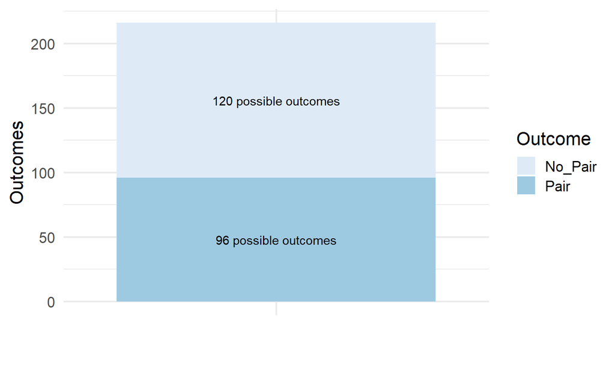